# Practice #3

Y.Burankova, A.Tokareva, M.Fofanov

24.11.2021

# Import and data checking

## Import required library

**tidyverse** library ver. 1.3.1 is used for processing data. **car** library ver. 3.0.10 is used for ANOVA test, **multcomp** library ver. 1.4.17 is used for post hoc.

This tidyverse library include all required libraries:  
- **ggplot2** 3.3.3, for data visualization.  
- **dplyr** 1.0.5, for data manipulation.  
- **tidyr** 1.1.3, for data tidying.  
- **readr** 1.4.0, for data import.  
- **purrr** 0.3.4, for functional programming.  
as well as tibble ver. 3.1.0, stringr ver 1.4.0, ver. forcats 0.5.1.

## 1. Import .csv data

### Function for reading .csv files and writing it to just one .csv file

Function for reading all files with the required format (in this case mainly .csv) on a given path and writing all this data into one ‘all_in_one.csv’ file in the same folder.

The function also returns data from the resulting ‘all_in_one.csv’ file.

```r
read_patients_data <- function(path, file_type) {
  list.files(path = path,
             pattern = paste('*.', file_type, sep=''),
             full.names = TRUE) %>%
    map_df(~read_csv(., col_types = cols(.default = "c"))) %>%
    distinct(.) %>%
    write_csv(., paste(path, "all_in_one.csv", sep=''))

  return(read_csv(paste(path, "all_in_one.csv", sep='')))
}
```

We load data from all .csv files into one variable using the above function. In our case, the data is in the ‘./Data/’ folder.

There are 200 rows and 7 variables in the data.

## 2. Check and fix the data

For each column, we check for wrong values:  
- if we know the missing (incorrectly recorded) value - we change it.  
- if we don`t know - change to NA.

Thus, we will save the maximum information about each of the patients.

The data:

| X1 | gender | age | drug_type | is_relapse | id | days_in_hospital |
| --- | --- | --- | --- | --- | --- | --- |
| 1 | female | 26 | Placebo | 0 | 101 | 25.1824 |
| 2 | female | 26 | Placebo | 1 | 102 | 23.2693 |
| 3 | female | 31 | Placebo | 0 | 103 | 29.8672 |
| 4 | female | 28 | Placebo | 1 | 104 | 27.8208 |
| 5 | female | 29 | Placebo | 1 | 105 | 23.2787 |
| 6 | female | 30 | Placebo | NA | 106 | 24.6678 |

### X1 column

This column is present in the initial data, but does not carry any information other than the order in which patient data is written to the files. We can remove it.

### ‘gender’ column

We check it for missing and incorrectly entered values and transform it to factor.

We have several incorrectly entered values, let’s correct it and transform column to factor.

There are 0 NA values in this column.

### ‘age’ column

Check it for missing and incorrectly entered values and transform to numeric.

We have several incorrectly entered values (not a numbers), let’s correct it and transform column to factor.

| gender | age | drug_type | is_relapse | id | days_in_hospital |
| --- | --- | --- | --- | --- | --- |
| male | thirty-one | New_type_1 | 1 | 44 | 25.6725 |
| male | thirty-one | New_type_1 | 0 | 48 | 12.6146 |
| male | thirty-one | New_type_1 | 1 | 45 | 29.8266 |

Let’s check if the entered values (outliers, more then +- 3 sd) are wrong. Since we cannot correct these values to valid, we correct them to NA.

| gender | age | drug_type | is_relapse | id | days_in_hospital |
| --- | --- | --- | --- | --- | --- |
| male | 350 | Old_type | 0 | 51 | 21.5715 |
| male | 220 | Old_type | 0 | 67 | 21.4886 |

There are 2 NA values in this column.

### ‘drug_type’ column

Check it and transform to factor.

| drug_type | number_observations |
| --- | --- |
| New_type_1 | 50 |
| New_type_2 | 50 |
| Old_type | 50 |
| Placebo | 50 |

There are 0 NA values in this column.

### ‘is_relapse’ column

| is_relapse | number_observations |
| --- | --- |
| 0 | 101 |
| 1 | 89 |
| NA | 10 |

Check it and transform to factor with two labels: “not_relapsed”, “relapsed”.

There are 10 NA values in this column.

### ‘id’ column

Transform it to numeric and move it to the beginning of the dataset.

There are 0 NA values in this column.

### ‘days_in_hospital’ column

Check it for missing and incorrectly entered values and transform to numeric.

| id | gender | age | drug_type | is_relapse | days_in_hospital |
| --- | --- | --- | --- | --- | --- |

There are 0 NA values in this column.

# EDA

The data:

|  | id | gender | age | drug_type | is_relapse | days_in_hospital |
| --- | --- | --- | --- | --- | --- | --- |
| 1 | 101 | female | 26 | Placebo | not_relapsed | 25.1824 |
| 2 | 102 | female | 26 | Placebo | relapsed | 23.2693 |
| 3 | 103 | female | 31 | Placebo | not_relapsed | 29.8672 |
| 4 | 104 | female | 28 | Placebo | relapsed | 27.8208 |
| 5 | 105 | female | 29 | Placebo | relapsed | 23.2787 |
| 6 | 106 | female | 30 | Placebo | NA | 24.6678 |

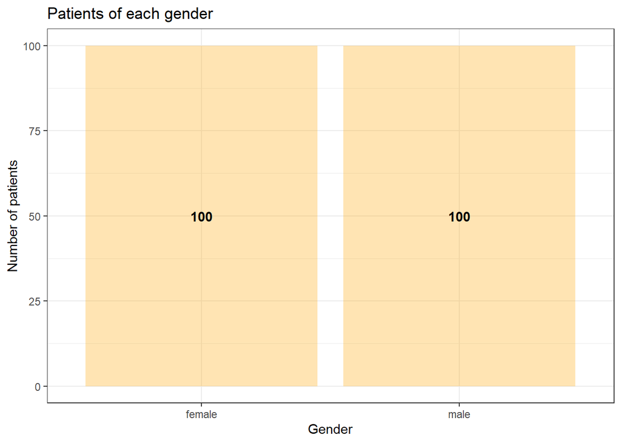

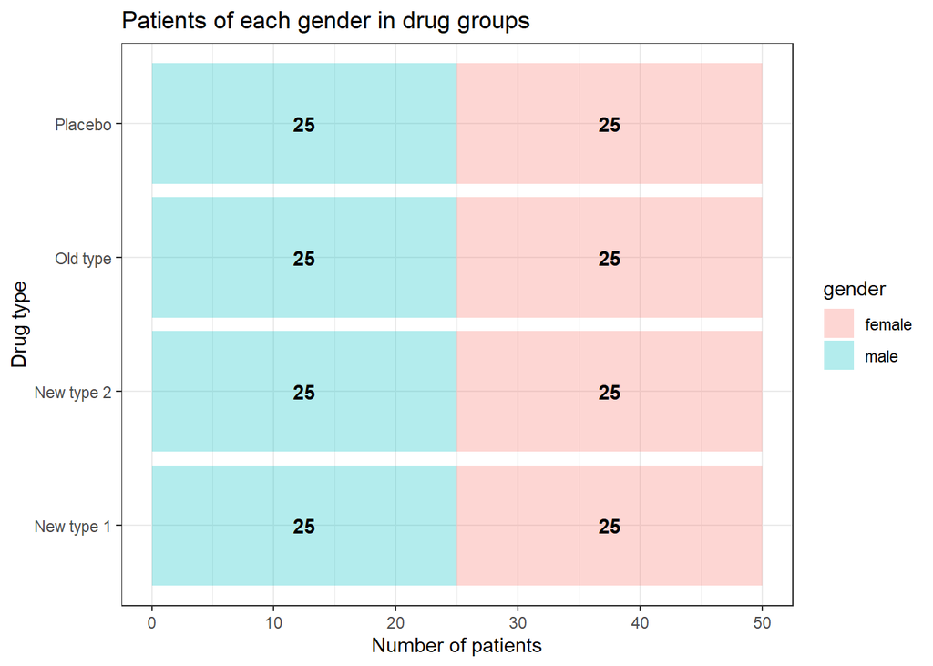

We have the same number of patients in groups of different sex and in groups who took different drugs.

Outcomes in different drug groups:

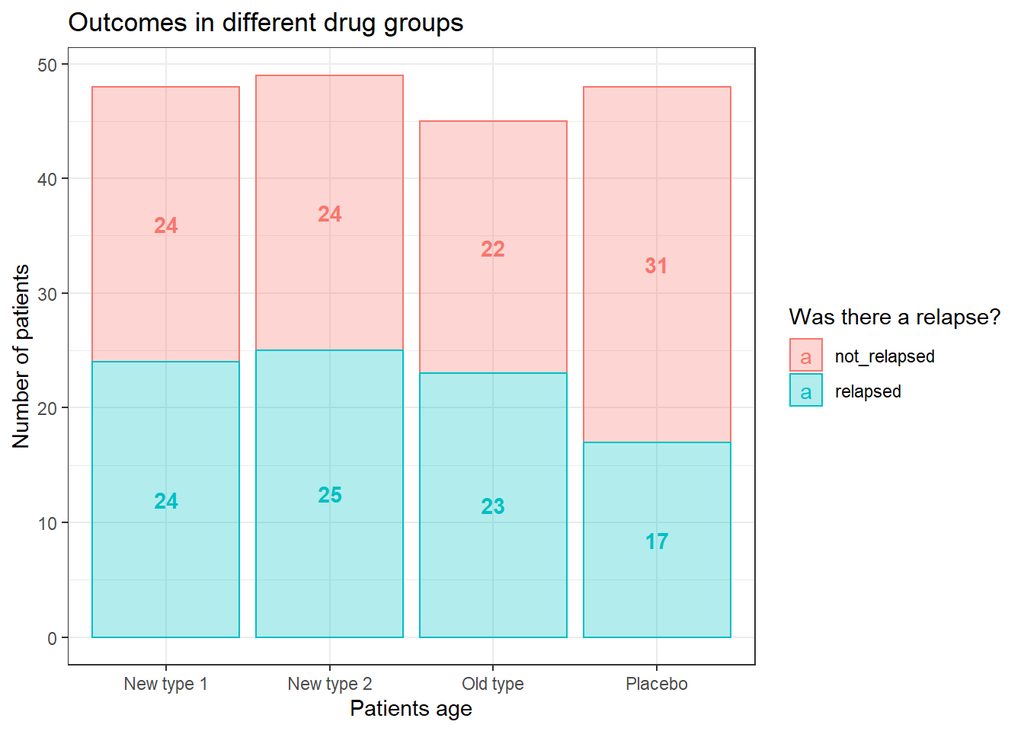

## Age distribution

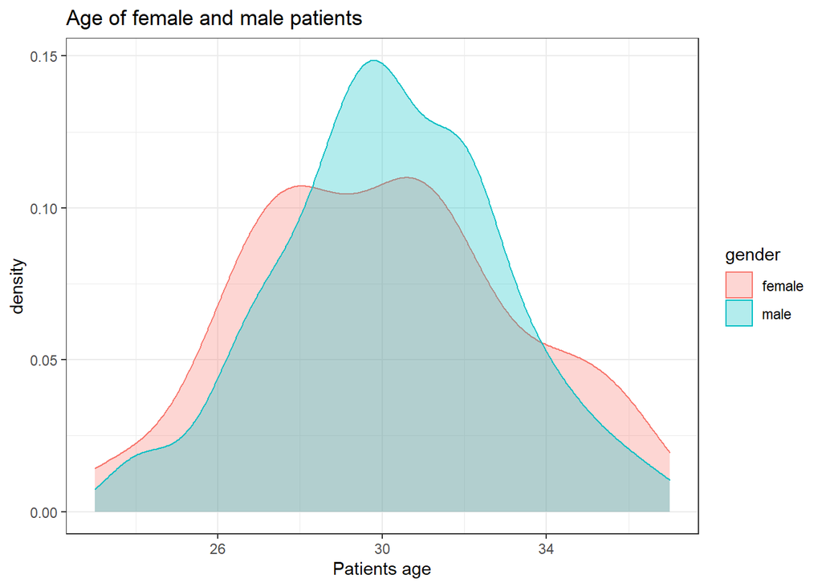

We have done the Shapiro-Wilk normality test for Age of patients. The results of group age distribution, number of observations, p-values and W statistics:

| Group | Number of observations | W statistics | p_value | Distribution |
| --- | --- | --- | --- | --- |
| all patients | 198 | 0.984203 | 0.0255114 | Not normal |
| female patients | 100 | 0.977667 | 0.0873230 | Normal |
| male patients | 98 | 0.983712 | 0.2679375 | Normal |

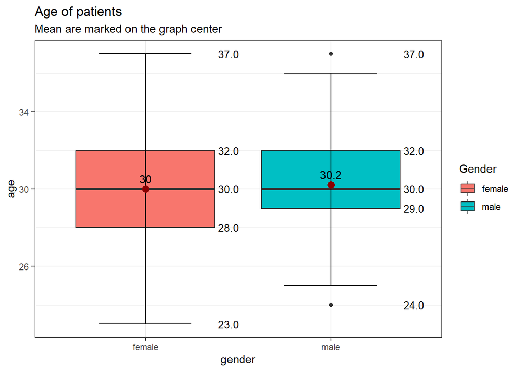

On the side of each graph are indicated: maximum value, 3rd quartile, median, 1st quartile, minimum value.

## Days in hospital distribution

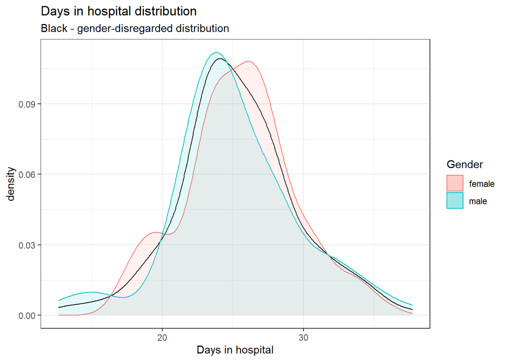

We have done the Shapiro-Wilk normality test for number of days in hospital for patients. The results of group distribution, number of observations, p-values and W statistics:

| Group | Number of observations | W statistics | p_value | Distribution |
| --- | --- | --- | --- | --- |
| all patients | 200 | 0.988328 | 0.1009467 | Normal |
| female patients | 100 | 0.986247 | 0.3890254 | Normal |
| male patients | 100 | 0.969734 | 0.0210943 | Not normal |

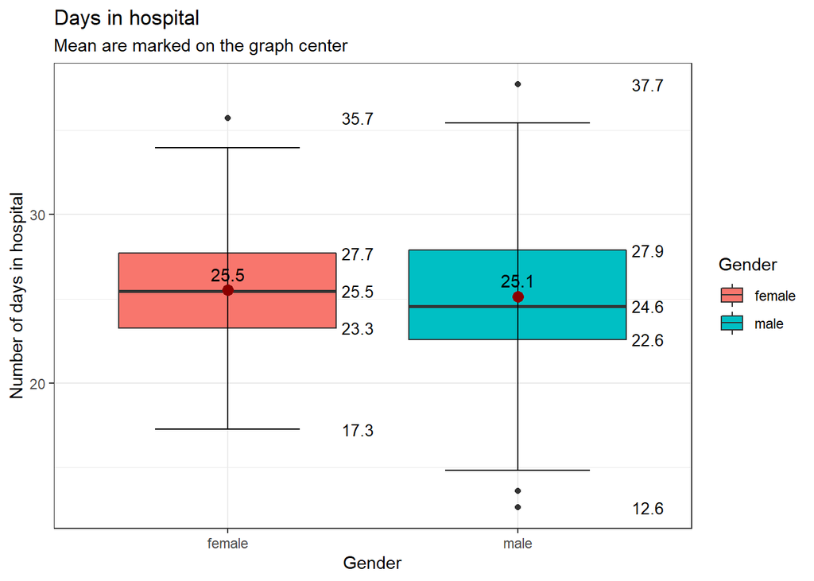

On the side of each graph are indicated: maximum value, 3rd quartile, median, 1st quartile, minimum value.

## Days in hospital distribution for different drug types

### Female patients

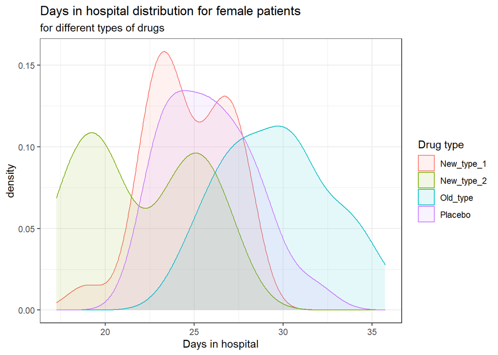

We have done the Shapiro-Wilk normality test for number of days in hospital for female patients. The results of group distribution, number of observations, p-values and W statistics:

| Female Group | Number of observations | W statistics | p_value | Distribution |
| --- | --- | --- | --- | --- |
| New type 1 | 25 | 0.935588 | 0.117026 | Normal |
| New type 2 | 25 | 0.899846 | 0.018205 | Not normal |
| Old type | 25 | 0.974424 | 0.757475 | Normal |
| Placebo | 25 | 0.958850 | 0.392042 | Normal |

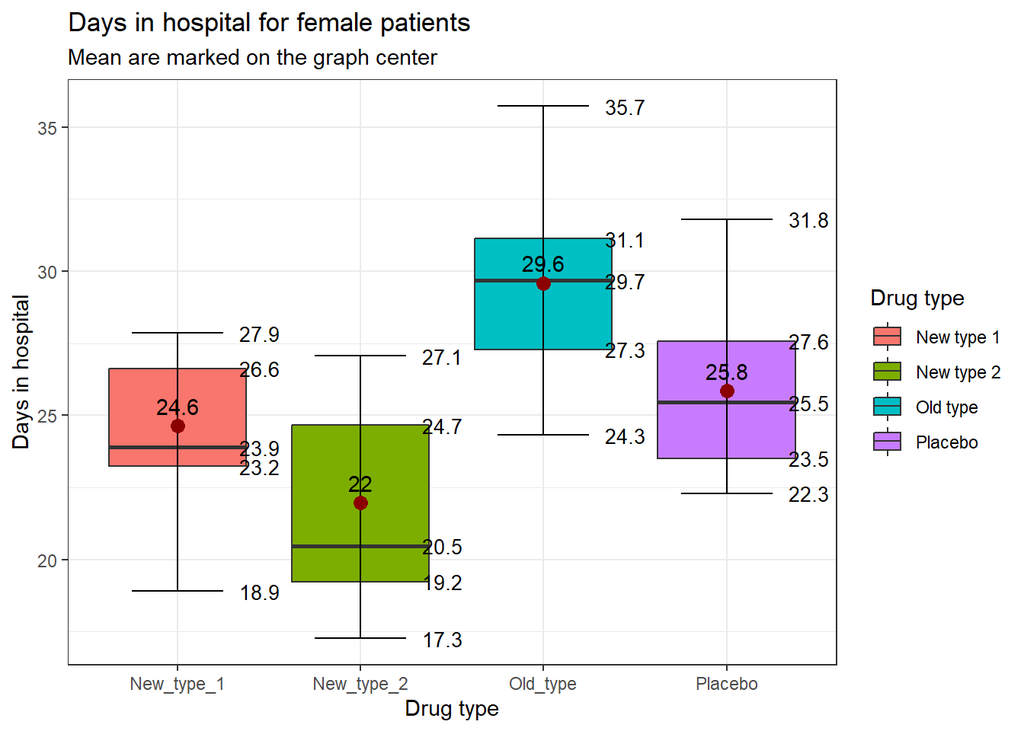

On the side of each graph are indicated: maximum value, 3rd quartile, median, 1st quartile, minimum value.

### Male patients

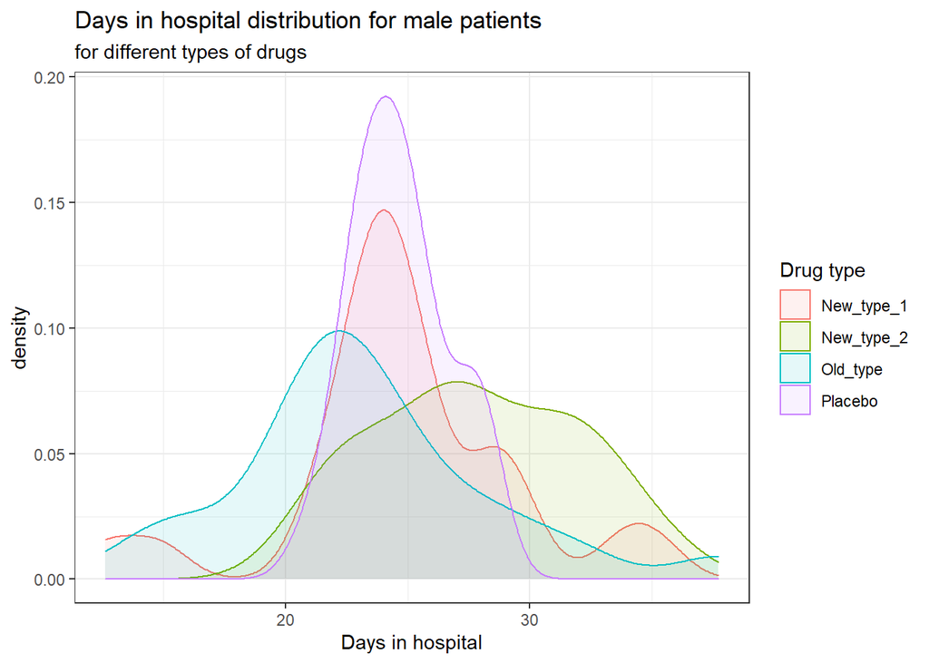

| Male Group | Number of observations | W statistics | p_value | Distribution |
| --- | --- | --- | --- | --- |
| New type 1 | 25 | 0.923390 | 0.0612344 | Normal |
| New type 2 | 25 | 0.962311 | 0.4624033 | Normal |
| Old type | 25 | 0.956131 | 0.3428173 | Normal |
| Placebo | 25 | 0.960253 | 0.4195448 | Normal |

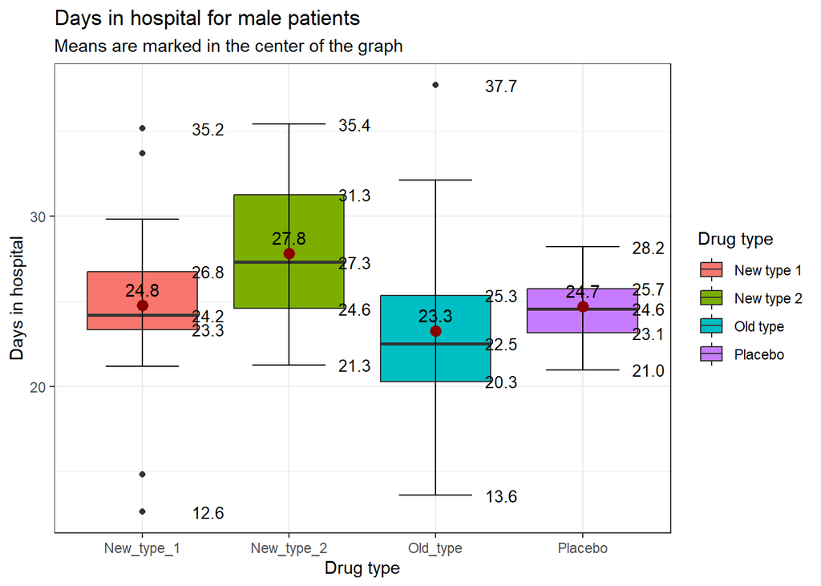

On the side of each graph are indicated: maximum value, 3rd quartile, median, 1st quartile, minimum value.

## The numbers of day required for a recovery (regardless of the gender)

The average for the numbers of day required for a recovery is 25.323.

The standard deviation equals to 4.197.

## Visualisation of days spent in hospital for male and female patients (Q.4)

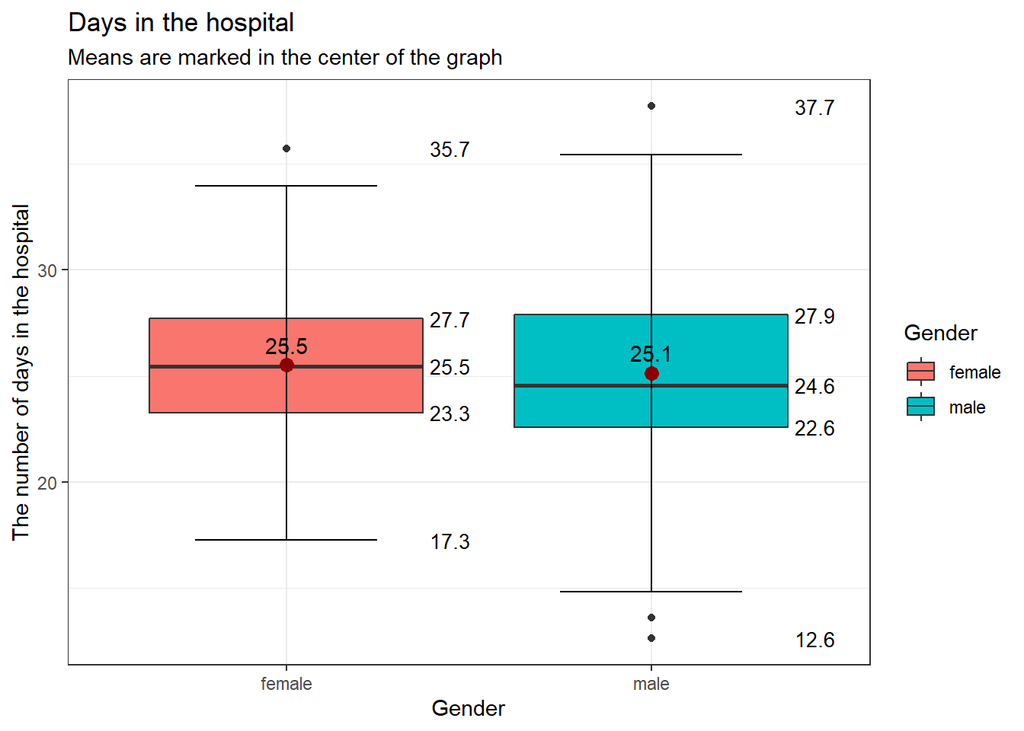

# The difference between the number of days spent in hospital for female patients, that took in placebo and female patients who took drug type 2

#### Data extraction

At first, we extracted 2 vectors from our data frame - ‘female’ patients and ‘placebo’ and ‘female’ patients and ‘New_type_2’.

#### Normality check

In the subsequent stage we need to check the distribution for normality.

We done the Shapiro-Wilk normality test for number of days in hospital for female patients in the ‘placebo’ group.

According to the Shapiro-Wilk normality test, we cannot reject the null hypothesis (the distribution is normal). W = 0.95885, p-value = 0.392042, Number of observations = 25.

Also we done the Shapiro-Wilk normality test for number of days in hospital for female patients in the ‘New_type_2’ group.

According to the Shapiro-Wilk normality test the the distribution in the second group can be considered not normal. W = 0.899846, p-value = 0.018205, Number of observations = 25 (p-value = 0.018205 < 0.05, the difference is statistically significant).

#### Mann-Whitney U test

The distribution in the second group is not normal and the groups are not big enough, therefore we decided to use nonparametric Mann-Whitney U test.

The differences are statistically significant (W = 497, p-value = 0.000221, p-value is below the chosen threshold of 0.05), therefore we can reject the null hypothesis (P(X > Y) = P(X < Y)) in favor of the alternative hypothesis: **There is a statistically significant difference between the number of days spent in hospital for female patients, that took in placebo and female patients who took drug type 2**.

Then we used one-sided test:

The differences are statistically significant (W = 497, p-value = 0.00011, p-value is below the chosen threshold of 0.05), therefore we can reject the null hypothesis (P(X > Y) = P(X < Y)) in favor of the alternative hypothesis: **The number of days spent in hospital for female patients, that took in placebo was greater, than for female patients who took drug type 2**.

#### Visualization

The difference between groups can be visualized via the boxplot:

[figure not shown]

# Is there a difference between the number of days for each drug or placebo?

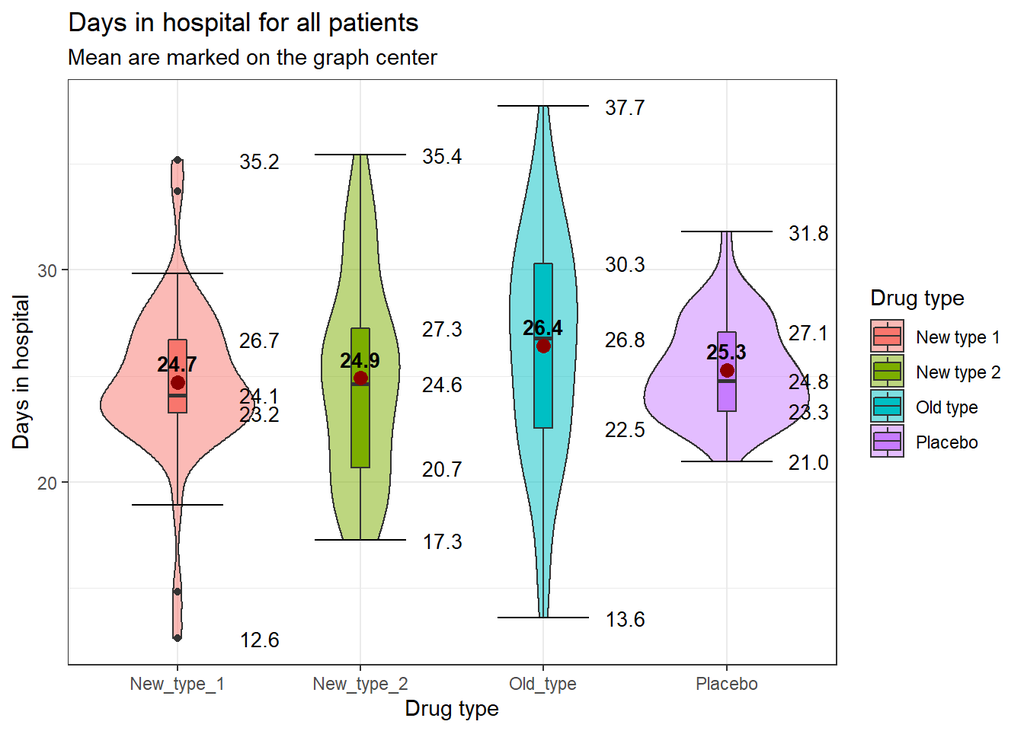

We fit a linear regression model to the data and perform a Shapiro-Wilk statistical test to test the residuals for normality:

```
##
## Call:
## lm(formula = days_in_hospital ~ drug_type, data = patients)
##
## Residuals:
##     Min      1Q  Median      3Q     Max
## -12.832  -2.205  -0.261   2.283  11.302
##
## Coefficients:
##                     Estimate Std. Error t value Pr(>|t|)
## (Intercept)           24.701      0.590   41.83   <2e-16 ***
## drug_typeNew_type_2    0.195      0.835    0.23    0.815
## drug_typeOld_type      1.721      0.835    2.06    0.041 *
## drug_typePlacebo       0.570      0.835    0.68    0.496
## ---
## Signif. codes:  0 '***' 0.001 '**' 0.01 '*' 0.05 '.' 0.1 ' ' 1
##
## Residual standard error: 4.18 on 196 degrees of freedom
## Multiple R-squared:  0.0254, Adjusted R-squared:  0.0105
## F-statistic:  1.7 on 3 and 196 DF,  p-value: 0.168
```

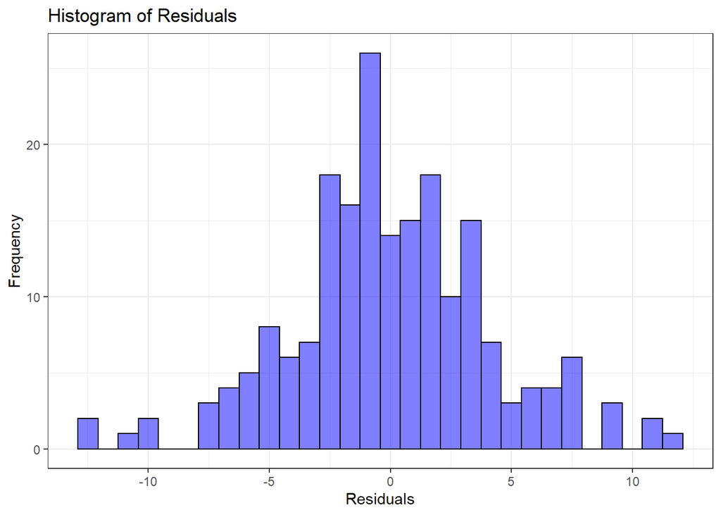

The residuals of the linear regression model is **normally distributed**. Shapiro-Wilk normality test p-value = 0.071 (number of observations is 200, W statistics is 0.987)

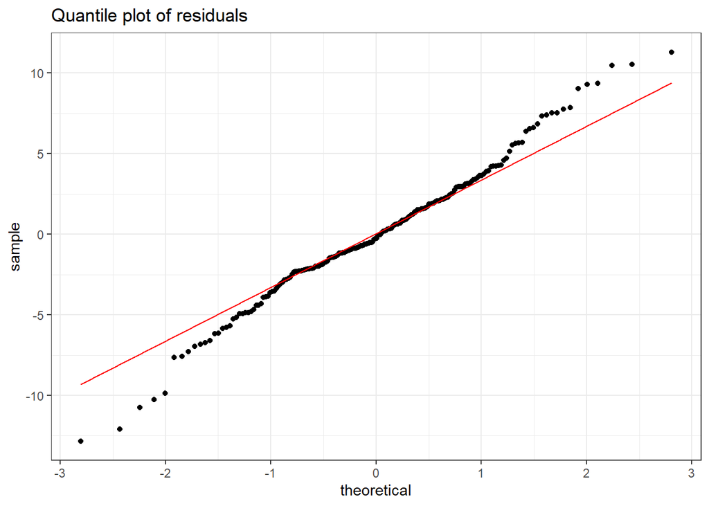

We have a spread of variances in groups, but since we have an equal number of observations in each of the groups, we accept it as possible to carry out one-way analysis of variance.

**The number of days in the hospital does not depend on the medicine chosen (F = 1.701171, p_value = 0.168101 , df_1 = 3, df_2 = 196)**.

#### Perform the post-hoc (TUKEYS HSD)

**To identify pairwise differences, the Tukey post-hock test was performed (df = 196). There were no statistically significant differences in the number of days in the hospital when pairwise comparison of the intake of various drugs**:

```
##
##   Simultaneous Tests for General Linear Hypotheses
##
## Multiple Comparisons of Means: Tukey Contrasts
##
##
## Fit: lm(formula = days_in_hospital ~ drug_type, data = patients)
##
## Linear Hypotheses:
##                              Estimate Std. Error t value Pr(>|t|)
## New_type_2 - New_type_1 == 0    0.195      0.835    0.23     1.00
## Old_type - New_type_1 == 0      1.721      0.835    2.06     0.17
## Placebo - New_type_1 == 0       0.570      0.835    0.68     0.90
## Old_type - New_type_2 == 0      1.526      0.835    1.83     0.26
## Placebo - New_type_2 == 0       0.374      0.835    0.45     0.97
## Placebo - Old_type == 0        -1.151      0.835   -1.38     0.51
## (Adjusted p values reported -- single-step method)
```